# Sentiment Analysis Badge

# Small k (3)

```
## A topic model with 3 topics, 5781 documents and a 7820 word dictionary.
```

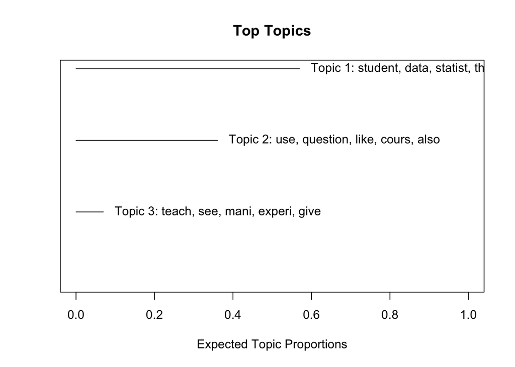

# Large k (30)

```
## A topic model with 30 topics, 5781 documents and a 7820 word dictionary.
```

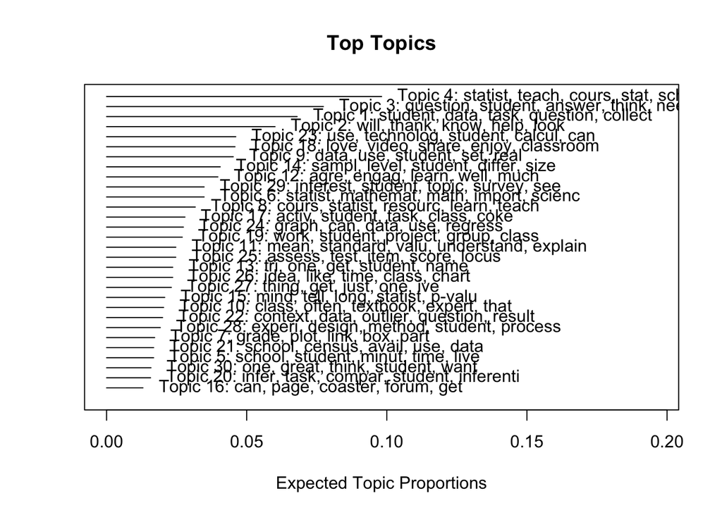

### Knit & Submit

Congratulations, you’ve completed your Intro to text mining Badge! Complete the following steps to submit your work for review:

1. Change the name of the `author:` in the [YAML header](https://monashdatafluency.github.io/r-rep-res/yaml-header.html) at the very top of this document to your name. As noted in [Reproducible Research in R](https://monashdatafluency.github.io/r-rep-res/index.html), The YAML header controls the style and feel for knitted document but doesn’t actually display in the final output.
2. Click the yarn icon above to “knit” your data product to a [HTML](https://bookdown.org/yihui/rmarkdown/html-document.html) file that will be saved in your R Project folder.
3. Commit your changes in GitHub Desktop and push them to your online GitHub repository.
4. Publish your HTML page the web using one of the following [publishing methods](https://rpubs.com/cathydatascience/518692):
   - Publish on [RPubs](https://rpubs.com) by clicking the “Publish” button located in the Viewer Pane when you knit your document. Note, you will need to quickly create a RPubs account.
   - Publishing on GitHub using either [GitHub Pages](https://pages.github.com) or the [HTML previewer](http://htmlpreview.github.io).
5. Post a new discussion on GitHub to our [Text mining Badges forum](https://github.com/orgs/laser-institute/teams/network-analysis/discussions/3). In your post, include a link to your published web page and a short reflection highlighting one thing you learned from this lab and one thing you’d like to explore further.